# Trans Rights Research

Faith Greene, Minsuh Kim, Fila Mohamed, Hana Pham

2/16/2022

###### Code Name: Trans-Data

##### Project Title: Trans Rights Research

##### Authors

- Minsuh Kim (msk812@uw.edu)
- Faith Greene (bag01@uw.edu)
- Hana Pham (hanapham@uw.edu)
- Fila Mohamed (fila10@uw.edu)

##### Affiliation

INFO-201: Technical Foundations of Informatics- The Information School University of Washington

##### Abstract

Our project attempts to address the issues surrounding the availability of trans healthcare regarding medically transitioning impacts on the rates of trans suicide and transphobic hate crimes. This is essential to address because data on trans populations are often unknown to the general populous, and bringing awareness to this topic would increase the amount of available data to help continue the fight for trans rights. To address this concern, we plan to look at available data sets and analyze if the rates of suicide and hate crimes change before and after, in a place, and with or without the availability of transition healthcare.

##### Keywords

- *Trans Rights*
- *Trans Suicide*
- *Medical Transitioning Impacts*
- *Trans Hate Crimes*

##### Introduction

Our project takes on problems surrounding Trans rights and their overall livelihood in the United States. The trans community has been subject to oppression both on social media and in real life. We as a group have decided to shed light on issues specifically in the trans community that is affected by outside factors. Some of these factors include hate crimes and lack of medical resources or support related to the patient’s choice of transitioning. We are connecting and comparing these outside factors mentioned to the rate of suicide in the trans community. Our data set will consist of hate crimes(against trans) count in various months; also, a second data source will contain the number of self-harm within the community each month. We will make sure to update our data as our questions become specific, and as such, we can retrieve our answers from each data source.

##### 2.0 Design Situation: You may find it helpful to include a figure.

###### - *Framing the topic of concern:*

The topic of concern is the effect of the availability of trans healthcare on the trans population concerning trans suicides. A key element would be trans rights. A lack of trans rights is solely a social justice problem that hinders trans peoples’ ability to transition fully.

###### - *Human Values:*

The principal human value we’re emphasizing with our chosen topic is equal rights and accepting people for who they are. These values come from providing trans people with the medical tools and access to transition to being who they are. We chose this topic to draw attention to the issues surrounding trans rights and emphasize the detrimental results of these hate crimes. A considerable tension from this could be those who don’t believe in providing the trans populous access to medical care because of their ignorance.

###### - *Stakeholders:*

The direct stakeholders of our topic are the general population. We’re motivated to raise awareness on injustices towards trans people, resulting in increasing numbers of suicides. We’re also bringing to light the problems surrounding the lack of availability of trans healthcare. Indirect stakeholders could be policymakers who can make a difference in making trans healthcare accessible for everyone. Other stakeholders include those within the medical field. Doctors or nurses all within the profession have the voice and access to create some change and advocacy for trans people. By displaying all this information, it may encourage some advocates within the specific work field to open up the possibilities of change.

###### - *Benefits & Harms:*

A potential benefit would be a change surrounding the availability of trans healthcare. If this information were to incite any positive outcome, this would be by far the greatest. It would mean that the data we presented provoked some feelings of action and realization that something must change. That means it reached every audience we intended to target: policy makers, doctors, the general population and medical professionals. Some unanticipated consequences could be that our presentation of data doesn’t motivate the effort that we hoped would happen. In other words, there continues to be no advocation towards equality for trans people.

##### 4.0 The Dataset

As of writing, we have 3 data sets, though we may add more if we find relevant datasets that make up for limitations. While we do have a later section on limitations as part of my analysis of the three datasets, I will mention the limitations of each. Our first dataset comes courtesy of the Trans Day of Remembrance organization that consolidated data from the Trans Murder Monitoring Project and Transgender Europe. Of all the datasets, this is one I, Faith, trust the most, as it was collected with the purpose of furthering transgender rights all over the world. Now the data itself has 4034 entries, with 21 data points per entry, though most probably won’t be of use for this project, but are still haunting, with 3 data points being different links to a more detailed site about each victim. But it would be remiss of me to not mention the limitations, namely that the data is all *reported* deaths, we don’t know how many who died were just not reported or the reports lost, not to mention that those who die in the closet won’t be reported in such a way to make it onto the dataset, thus our data is incomplete. Our second dataset comes courtesy of the FBI and it records hate crimes since 1991, has 28 data points and 1,318,023 entries, most of this data won’t be relevant, as we care only about anti-trans hate crime, but the dataset does record the type of hate crime…. but only after 2014, so we will be missing a lot of hate crimes for the times where I, Faith, would expect them to be in their heyday in the US. Now because this is the FBI reporting, many hate crimes committed by police are probably not reported. However, on the whole, I expect what is reported to be true. The last dataset is compiled by Faith Greene (me) from https://www.lgbtmap.org/equality-maps/healthcare_laws_and_policies using the Wayback Machine at https://web.archive.org/ to approximate dates, and it of all 50 states, DC, and most of the territories laws on healthcare for trans individuals. Pinning down dates before may 5th 2015 would take more time than I have to spend on this project, because the Wayback machine does not have captures of my source from before that date, meaning I’d have to dig into states’ legislative histories. Now I had to take this imprecise method because there aren’t really datasets on the history of this subject, as most people care about the now in this scenario, and rightfully so. But this means my data is really untrustworthy because I spent over 8 hours compiling it by noting differences in the non-CSV table the site uses and recording when each change occurred, so exact dates are wrong by at bests a few days, but if I missed something big, it could be months. Also, I didn’t record everything I could, only recording whether there were private insurance anti-discrimination laws, laws for or against the exclusion of trans-specific care for private insurance, and whether Medicaid provided trans-specific care. I did not monitor whether state employees had trans benefits to ease the burden on myself, I also have not accounted for how many people have access to insurance nor how many doctors in a particular area are available. Were I to have more than a few days to spend on this, and more people to help, the data would be a lot better, but for now, it will have to do.

##### 6.0 Limitations

A considerable limitation we face with this topic is a limited pool of information on our choice. We want to make sure we deliver an adequate and effective amount of data to get the outcome we’re anticipating. If we don’t provide the data in a way that’s easy for everyone to understand the message we’re portraying, we would have failed in the goal we’re attempting to meet in raising attention on the injustices towards transgender people. We’re limited in the types of data sets, not just the amount of data. We want to find ones that can show the relationship between trans hate crimes and the lack of social and medical support for the transgender community. There is one other limitation as well, there is no good metric for access to trans healthcare, because it’s a multifaceted issue. There could be transition care that’s easy and cheap to get as cough syrup, but if the environment is hostile to trans people, that care is going to be taken advantage of less. And so, our ‘independent variable’, so to speak, is affected by our ‘dependent variable’, but our dataset can’t really adapt to this.

###### Acknowledgements

We would like to thank our fellow peers for helping us find some data sets.

###### References

- *Study shows shocking rates of attempted suicide among Trans Teens*. HRC. (n.d.). https://www.hrc.org/news/new-study-reveals-shocking-rates-of-attempted-suicide-among-trans-adolescen
- Unger, C. A. (2016, December). *Hormone therapy for transgender patients*. Translational andrology and urology. https://www.ncbi.nlm.nih.gov/pmc/articles/PMC5182227/
- Rangel, A. (2022, February 2). *A blueprint for reform: Police and transgender rights*. The Crime Report. https://thecrimereport.org/2022/02/02/a-blueprint-for-reform-police-and-transgender-rights/
- *Understanding the transgender community*. HRC. (n.d.). https://www.hrc.org/resources/understanding-the-transgender-community

## Summary

### Summary Table

| Year | Deaths by Hate Crime | Deaths by Suicide | Hate Crimes | Avg trans care score assinged per year |
| --- | --- | --- | --- | --- |
| 1970 | 1 | NA | NA | NA |
| 1972 | 1 | NA | NA | NA |
| 1973 | 2 | NA | NA | NA |
| 1974 | 2 | NA | NA | NA |
| 1975 | 4 | NA | NA | NA |
| 1976 | 3 | NA | NA | NA |
| 1977 | 6 | NA | NA | NA |
| 1979 | 3 | NA | NA | NA |
| 1980 | 2 | NA | NA | NA |
| 1981 | 5 | NA | NA | NA |
| 1982 | 1 | NA | NA | NA |
| 1983 | 2 | NA | NA | NA |
| 1984 | 1 | NA | NA | NA |
| 1985 | 7 | NA | NA | NA |
| 1986 | 8 | NA | NA | NA |
| 1987 | 5 | NA | NA | NA |
| 1988 | 7 | NA | NA | NA |
| 1989 | 5 | NA | NA | NA |
| 1990 | 13 | NA | NA | NA |
| 1991 | 13 | NA | NA | NA |
| 1992 | 10 | NA | NA | NA |
| 1993 | 15 | NA | NA | NA |
| 1994 | 5 | NA | NA | NA |
| 1995 | 12 | NA | NA | NA |
| 1996 | 8 | NA | NA | NA |
| 1997 | 9 | NA | NA | NA |
| 1998 | 10 | NA | NA | NA |
| 1999 | 14 | NA | NA | NA |
| 2000 | 11 | 1 | NA | NA |
| 2001 | 13 | NA | NA | NA |
| 2002 | 16 | NA | NA | NA |
| 2003 | 16 | NA | NA | NA |
| 2004 | 16 | NA | NA | NA |
| 2005 | 17 | NA | NA | NA |
| 2006 | 8 | NA | NA | NA |
| 2007 | 6 | NA | NA | NA |
| 2008 | 19 | NA | NA | NA |
| 2009 | 13 | NA | NA | NA |
| 2010 | 9 | NA | NA | NA |
| 2011 | 14 | NA | NA | NA |
| 2012 | 14 | NA | NA | NA |
| 2013 | 22 | NA | 23 | NA |
| 2014 | 9 | 2 | 60 | NA |
| 2015 | 22 | 1 | 73 | 1.256426 |
| 2016 | 26 | NA | 106 | 1.456626 |
| 2017 | 29 | 1 | 107 | 1.580235 |
| 2018 | 27 | 9 | 143 | 1.723092 |
| 2019 | 27 | 7 | 158 | 1.786595 |
| 2020 | 36 | 8 | 224 | 1.926961 |

| State | Average Score | Hate Crimes |
| --- | --- | --- |
| AK | 2.00 | 1 |
| AL | 2.00 | NA |
| AR | 2.00 | 2 |
| AS | 2.00 | NA |
| AZ | 2.34 | 14 |
| CA | 2.00 | 206 |
| CM | 2.00 | NA |
| CO | 1.95 | 22 |
| CT | 1.15 | 1 |
| DC | 2.00 | 156 |
| DE | 0.91 | 2 |
| FL | 2.00 | 8 |
| GA | 2.00 | 3 |
| GU | 2.00 | NA |
| HI | 0.93 | 1 |
| IA | 1.31 | NA |
| ID | 2.00 | 1 |
| IL | 2.61 | 20 |
| IN | 2.00 | 3 |
| KS | 2.00 | 2 |
| KY | 2.00 | 15 |
| LA | 2.00 | NA |
| MA | 1.15 | 57 |
| MD | 1.68 | 10 |
| ME | 1.02 | 4 |
| MI | 0.14 | 11 |
| MN | 1.26 | 4 |
| MO | 2.00 | 10 |
| MS | 2.00 | NA |
| MT | 1.28 | 5 |
| NC | 2.00 | 3 |
| ND | 2.00 | 1 |
| NE | 2.00 | NA |
| NH | -0.26 | NA |
| NJ | 0.64 | 18 |
| NM | 0.82 | 5 |
| NV | 1.44 | 5 |
| NY | 1.79 | 75 |
| OH | 2.44 | 30 |
| OK | 2.00 | 2 |
| OR | 2.00 | 25 |
| PA | 0.65 | 5 |
| PR | 0.56 | NA |
| RI | 1.64 | 1 |
| SC | 2.00 | 5 |
| SD | 2.00 | 1 |
| TN | 2.00 | 5 |
| TX | 2.81 | 43 |
| UT | 2.00 | 5 |
| VA | 0.25 | 4 |
| VI | 2.00 | NA |
| VT | 2.00 | 2 |
| WA | 1.87 | 80 |
| WI | -0.63 | 5 |
| WV | 2.34 | 1 |
| WY | 2.00 | NA |

For the state bias we can find it here, use the average score and your own knowledge of what states are like, to see the problem I talked about with reporting.

### Chart 1 :

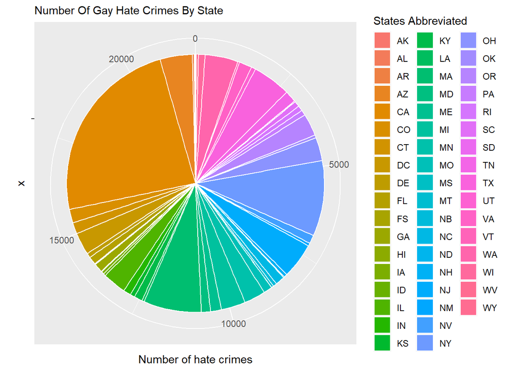

As I was creating this pie chart in relation to what Faith is talking about, its important to understand that the initialization of trans hate crime as a category is very recent, and up until 2013 it has been combined with gay hate crimes. Nonetheless its important to analyze the proportion of gay hate crimes by state. This insight allows to assess the relationship between trans hate crimes and the table of state scores allowing you to see where the disparities align.

## Chart 2 :

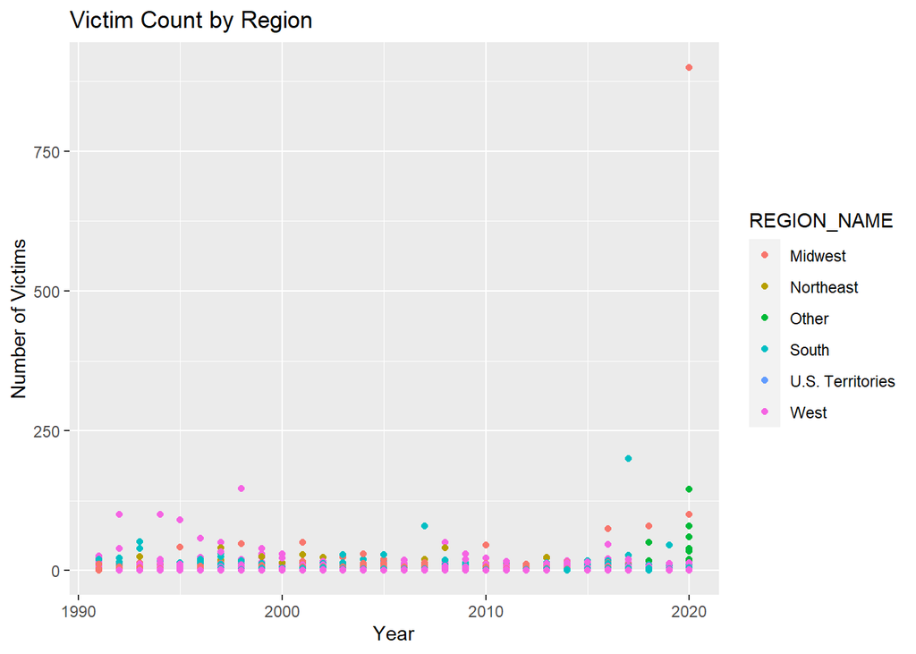

This scatter plot was meant to show the trends of the number of victim counts, from year 1990 to 2020, by varying regions of the United States. Something important about this data visualization are the different colors, which each represent a different region. It can show the distribution of regions that have more victims than others, simply by looking at the more pertinent colors. This data is meant to bring light to concentrated areas in the United States that still struggle with equal rights for the trans population, who are still victims of violence and hate crimes.

## Chart 3 :

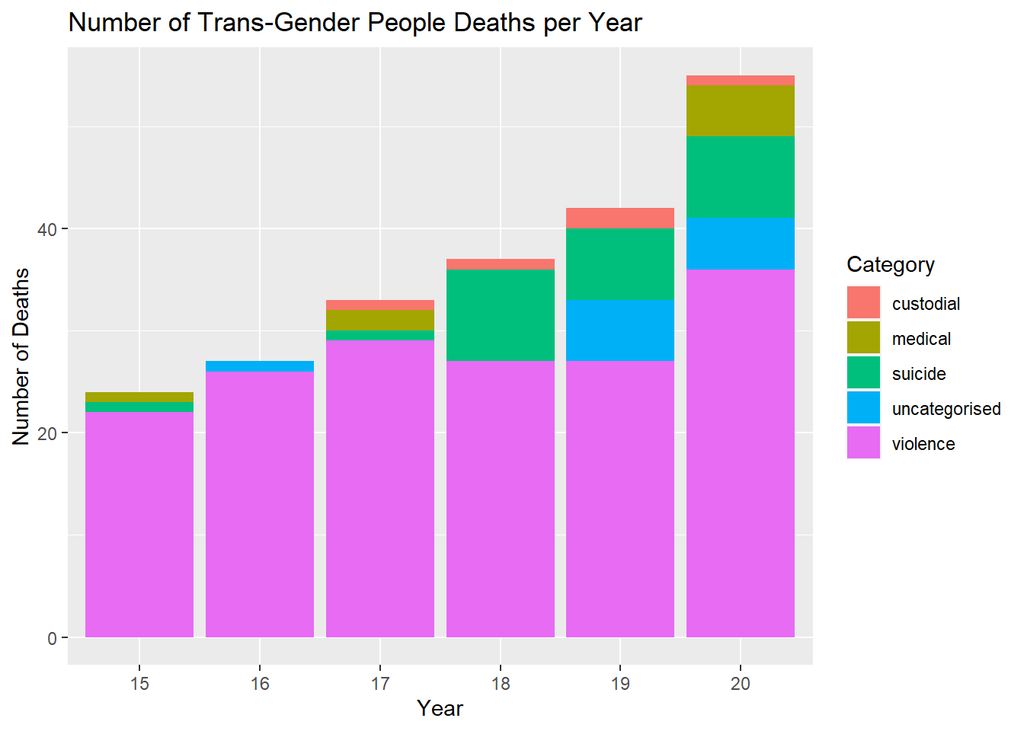

This stacked bar graph shows the number of deaths that Trans people have suffered, from 2015 to 2020, which is also separated based on the category of how they died. The different colors on the graph not only represent the different death categories, but they also demonstrate the frequency of deaths on one category. For example, according to the graph, the majority of Trans deaths were caused by violent actions of other people, which shows that many Trans people were victims of discrimination, hate crimes, and transphobia.